# Understanding the Increase in Drug Overdose and Alcohol Driving Deaths

Authors

Dennis Campoverde-Lema

Samantha Parras

Jodie Chen

Published

July 26, 2024

# Introduction

In 2022, 46.8 million Americans who were twelve years of age or older struggled with a drug use disorder. Eight million Americans aged twelve and older battled alcohol and drug use issues at the same time that year. Use of drugs and alcohol has substantial financial consequences. Every year, excessive alcohol use costs 249 billion dollars in lost productivity, medical expenditures, and criminal justice costs. In contrast, illicit drug usage costs 193 billion dollars in lost productivity, criminality, and medical costs. Communities can benefit from adopting and putting into practice policies that lessen prescription drug abuse and excessive alcohol consumption.

**Research Question:** Is there demographic and social factors that are predictors of drug overdose and alcohol-related incidents (e.g., driving accidents)?

**Hypothesis:** The chances of drug overdoses and alcohol-related driving incidents can be predicted by demographic factors like age, gender, and race as well as social factors like substance use habits, education, socioeconomic status.

Certain demographic variables—like age, gender, and race—have a major impact on the risk of drug overdoses and incidents involving alcohol and driving. For example, middle-aged people may be at risk from long-term substance use, while younger people may be at risk from peer pressure and experimentation. Another important factor is gender: it’s possible that men experience higher rates of substance abuse and related incidents than women do, possibly as a result of differing social behaviors and stress reactions. Differences in socioeconomic status, community support, and access to healthcare can all contribute to racial disparities. Social factors hold equal significance. Substance use patterns, such as the kind and quantity of drugs or alcohol consumed, are strong indicators of incidents linked to substance use. Furthermore, access to treatment or preventive resources, as well as patterns of substance use, can be influenced by socioeconomic status, which includes factors like education, work status, and income level. Tailored interventions can be devised through the identification and comprehension of these demographic and social variables. By customizing these interventions to target particular high-risk populations, their effectiveness can be increased and the population’s overall rate of drug overdoses and alcohol-related driving accidents can be decreased.

# Data

The data is collected by the University of Wisconsin Population Health Institute and includes health, clinical, social/economic, and demographic variables measured at the county level. The two response variables we are modeling are drug overdose rates and alcohol-impaired driving deaths. Drug overdose rates measure number of drug poisoning deaths per 100,000 from 2019-2021. Alcohol-impaired driving deaths measure the percentage of driving deaths with alcohol involvement from 2017-2021.

We considered the following social-economic and demographic variables:

**Unemployment:** Compared to the employed population, the unemployed population is known to excessively drink and do drugs more to cope with the stress from their financial situation.

**Median Income:** Higher income levels often correlate with better access to resources such as healthcare, education, and social services, which might reduce risky behaviors like excessive alcohol consumption and substance abuse.

**Disconnected Youth:** Disconnected youth is defined as the percentage of teens and young adults (ages 16-19) who are neighter working nor in school. Disconnected youth are more likely to smoke, drink, and use marijuana.They are also more prone to having mental health disorders

**High School Graduation:** A higher level of education is linked to a lower likelihood of smoking. Adults with higher levels of education typically have more employment opportunities and make more money overall.

**Social Associations:** Reduced participation in communal life and little social interaction with others are linked to higher rates of illness and early death. Compared to those with strong networks, those without strong social networks are less likely to choose healthy lifestyles.

Upon inspection, the variable of drug overdose deaths was found to have many N/A values, and it is important to ensure this variable is clean as it is one of the main variables to be analyzed. Additionally, rename the data so that it can be read easier and look presentable for any visuals.

# Intial EDA

Looking at the states with respect to drug overdose deaths and alcohol-impaired driving deaths, the areas with the most issues can be identified, and solutions can eventually be developed.

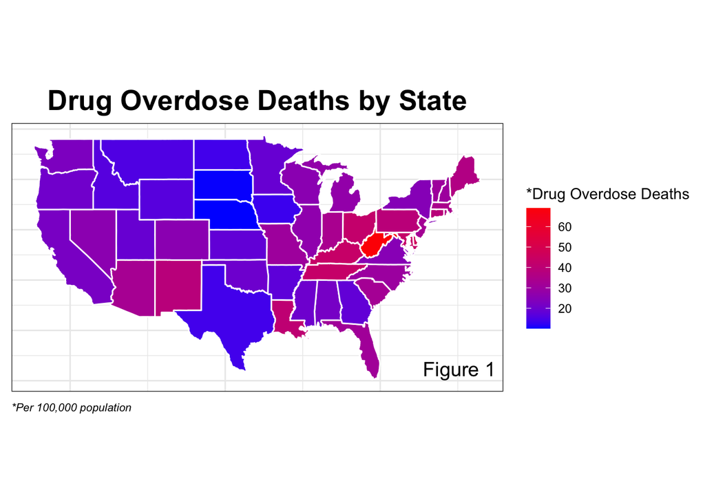

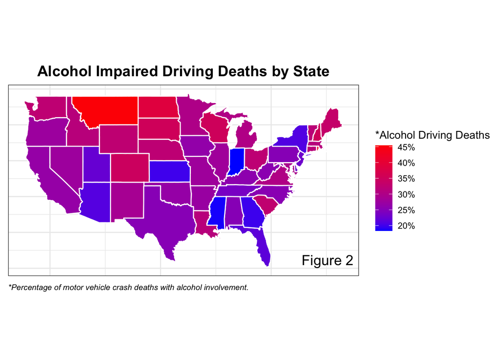

In **Figure 1**West Virginia has the highest amount of drug overdose deaths. By conducting further research on West Virginia, it was found that the state leads the nation in opioid-related drug overdose deaths. According to the Drug Enforcement Administration, West Virginia has one of the highest prescription rates for opioids in the country and also has a high prevalence of controlled prescription drug addiction and trafficking. Furthermore, the usage of illegal prescription drugs was a factor in almost 61% of state overdose deaths in 2015.

In **Figure 2** alcohol-impaired driving deaths, Montana had the highest amount of deaths resulting from alcohol-impaired driving. According to Forbes, Montana has the highest rate of drunk driving, with 8.57 fatal crashes involving drunk drivers for every 100,000 licensed drivers and 7.14 fatal crashes involving drunk drivers for every 100,000 state population. These rates are the highest in the country. Montana has the highest percentage of drunk drivers in the country—more than two-fifths (43.51%) of road fatalities.

By analyzing the predictors of both drug overdose deaths and alcohol-impaired driving deaths, solutions and regulations can hopefully be developed to help these states with their ongoing problems.

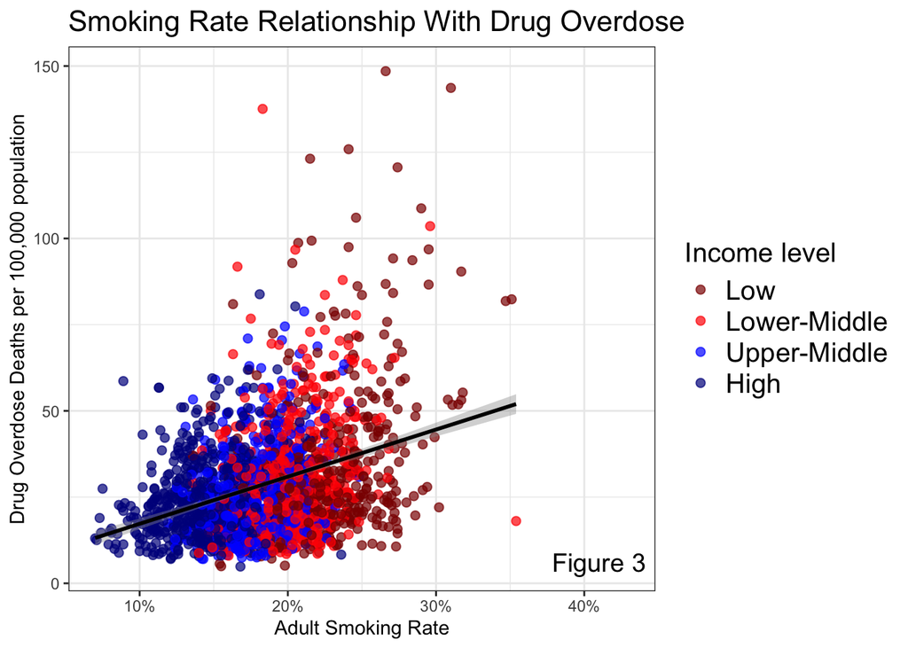

**Figure 3**, which is broken down by income level, shows the correlation between adult smoking rates and the number of drug overdose deaths per 100,000 people. The trend line shows a positive association, implying that there is a connection between an increase in drug overdose deaths and rising smoking rates. Dark red areas are low-income areas, which tend to cluster in the higher ranges of both smoking rates and overdose deaths. High-income areas, indicated in dark blue, on the other hand, typically have lower smoking rates and fewer overdose deaths.

# Methods

### Drug Overdose Rates

To model drug overdose rates, we used mixed effects model with random intercept to account for variability across geographical regions. We hypothesized that counties within the same region (e.g. state) are correlated–overdose death rates could vary by state due to differences in locally-regulated healthcare systems, law enforcement involving drugs, drug accessibility (variables not examined in the analysis). For example, West Virginia has by far the highest drug overdose deaths with opioid accounting for 83% of all drug overdose deaths in 2021. This is higher than the state average opioid overdose deaths accounting for 75% of drug overdose deaths. Uncoincidentally, this is attributed to West Virginia having the highest opioid prescription rate. This baseline variability could also be attributed to regional differences (across the US and within state) in specific drug availability and use.

Since counties could be correlated within different geographic region levels, we tested various mixed effects models with a random intercept term for:

**1. Urbanization level (three levels)**– CDC found that urban counties generally had higher drug overdoses due to higher population density and easier access to drugs from the greater number of distributors and markets in the cities.

**2. Public Health regions as defined by the U.S. Department of Health and Human Services**– Counties in these regions may vary in drug overdoses as different public health initiatives are implemented based on the specific needs of the territories/states within each region.

**3. The 50 states**–for reasons mentioned above.

We assumed that the effect of social and demographic predictors on drug overdose is constant, making the predictors fixed effects.

We included models with only fixed effects as controls to determine if random intercepts are even necessary. We used AIC–an approximation of leave-one-out cross validation–for model selection. The model is fit to n-1 observations to predict the response of one observation. This is done n times in which a different observation is left out from the training set each time.

Ultimately, the model with random intercepts for states has the lowest AIC and therefore the best fit.

```
               df      AIC
fixed_no_urban 11 15717.90
fixed_urban    12 15719.89
random_urban   12 15685.25
random_region  13 15412.36
random_state   13 15073.35
```

However, there is a cone shape pattern which indicates heteroscedastic.

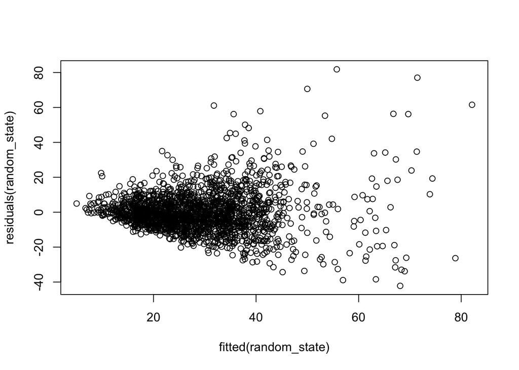

To resolve this, we applied a log transformation on Drug Overdose Deaths.

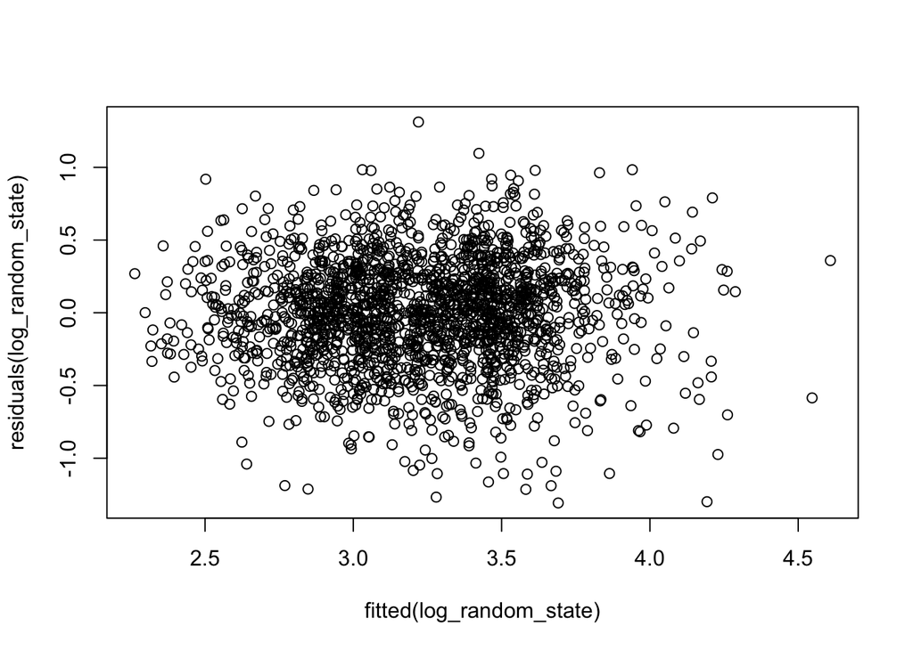

### Alcohol-impaired Deaths

To model alcohol-impaired deaths rate, we decided on a linear regression model and variations of linear regression–Ridge, Lasso, and Elastic Net to assist with feature selection. Ridge and Lasso regression are methods that reduce multicollinearity by imposing regularization penalties. Ridge is more conservative as it reduces the magnitude of coefficients by shrinking coefficients to near zero, while retaining all variables. Lasso on the other hand penalizes the model more by shrinking coefficients to exactly zero which removes unimportant variables from the model, making it extremely effective in reducing overfitting. Lasso Elastic Net is a balanced approach to variable selection and regularization that incorporates the strengths of both Ridge and Lasso. Finally, Random Forest, an ensemble method, is a potent instrument for managing intricate datasets due to its ability to capture non-linear relationships and interactions between variables, which provides both flexibility and robustness.

We used RMSE to determine the best model for alcohol-impaired driving deaths. To ensure that the model performance is not dependent on the train-test division of the dataset, we used a 5-fold cross validation that averages RMSE across the five folds.

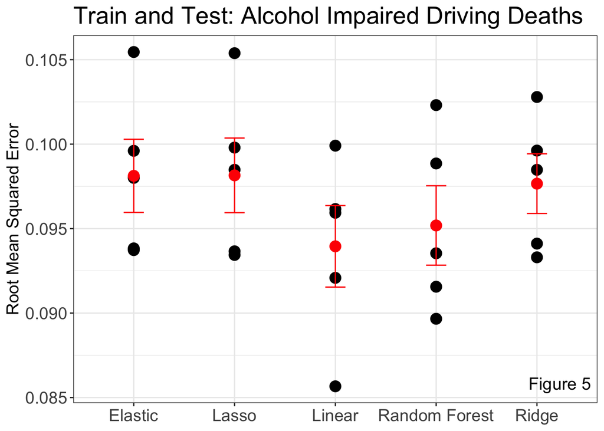

# Results

Looking at Alcohol Impaired Driving Deaths predictors using linear model lm() function. We also used 95% confidence intervals more more accurate results.

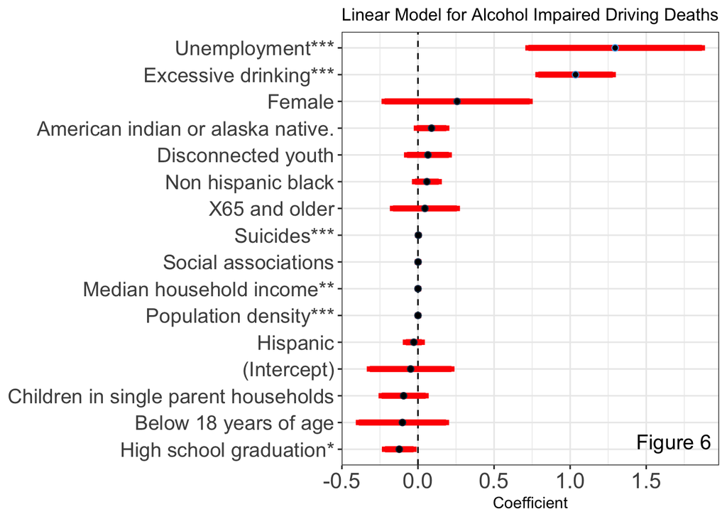

Looking at **Figure 6**, Unemployment is the top predictor for alcohol impaired driving deaths. Holding all other variables constant, if unemployment rate increases by 1%, alcohol impaired driving deaths is projected to increase by 1.3%. Other significant predictors are Excessive Drinking, Suicides, and Population Density.

# Discussion

A risk factor for substance abuse and drug use disorders is unemployment. According to the American Addiction Center, losing one’s job and money can cause psychological stress. This can then deteriorate one’s health and cause temporary coping mechanisms like substance abuse. Specifically, this indicates that losing one’s job is linked to an increased risk of alcohol-related health issues and the use of illegal drugs.

Further research from the American Addiction Center indicates that substance abuse problems are associated with an increased chance of unemployment because those who struggle with their use are more likely to take sick days and work less productively, both of which can lead to job loss. Furthermore, addiction also increases the difficulty of getting hired again or finding a new job.

## Ways to Reduce Unemployment

**Career pathways programs:** Programs for career pathways provide low-skilled people with occupation-specific training for higher-skilled roles in rapidly expanding industries including information technology, advanced manufacturing, and health care. These programs integrate social services with academic and technical education; many also include work experience (“Building Strong Middle-Class Career Pathways Programs”).

**Summer youth employment programs:** Summer youth employment programs give young people, often between the ages of 14 and 24, temporary jobs. Program organizers typically provide financial support for positions, and programs are managed by nonprofits or government organizations. Private sector businesses, on the other hand, could offer more competitive placements and pay participants directly. Programs may incorporate extra supports, such a work-readiness curriculum, and typically center on giving underprivileged youngsters options (“Youth Employment Programs”).

**Providing a generous tax credit for companies:** This will incentivize job creation by reducing the financial burden of hiring additional workers. This encourages businesses to expand their workforce, thereby reducing overall unemployment rates (Lerman).

## Limitations

Since we are working with county level data, all individuals’ data in a county are simply averaged which might mask important granular differences within counties. This could be an issue especially for larger counties that have multiple urban and rural areas and are therefore more socioeconomically and demographically diverse. For example, Los Angeles County is huge (population-wise) with 88 cities and nearly as many unincorporated areas. All these areas have vastly different socioeconomic conditions, access to healthcare, education levels, and employment opportunities. Aggregating by county masks these differences and makes it hard to generalize our findings. Additionally, drug overdose rates could vary by state depending on how strict the regulations are on drugs accessibility.

# Conclusion and Next Steps

To account for variability of drug overdoses, we can consider mixed effect models and try adding random intercept terms for state and urbanization level to effectively cluster the data by state or by urbanization level (rural, suburban, urban). This allows us to examine how geographic regions could impact the variability of baseline drug overdoses, highlighting more targeted and context-specific prevention and intervention programs.

In the future, identifying comparable datasets to impute data from and using methods such as k-nearest neighbors (KNN) or aggregating by state to fill in the missing data will be prioritized. This approach will enhance data completeness and reduce bias in our analyses.

# References

“Alcohol and Drug Abuse Statistics (Facts About Addiction).” American Addiction Centers, https://americanaddictioncenters.org/addiction-statistics. Accessed July 2024.

“Building Strong Middle-Class Career Pathways Programs.” Center for American Progress, https://www.americanprogress.org/article/building-strong-middle-class-career-pathways-programs/. Accessed 21 July 2024.

Generes, Wendy Manwarren. “Recession, Unemployment, and Drug Addiction: What’s the Link?” American Addiction Centers, 21 June 2024, https://americanaddictioncenters.org/blog/recession-unemployment-and-drug-addiction-whats-the-link. Accessed July 2024.

“Health Data.” County Health Rankings, https://www.countyhealthrankings.org/health-data. Accessed July 2024.

Lerman, Robert I. “Five Steps to Cut Unemployment.” Urban Institute, 4 Oct. 2011, https://www.urban.org/urban-wire/five-steps-cut-unemployment. Accessed 21 July 2024.

“The West Virginia Drug Situation.” DEA.gov, https://www.dea.gov/sites/default/files/2018-07/DEA-WAS-DIR-024-17%20West%20Virginia%20Drug%20Situation%20-UNCLASSIFIED.pdf. Accessed July 2024.

“Worst States For Drunk Driving In 2024 – Forbes Advisor.” Forbes, 3 May 2024, https://www.forbes.com/advisor/car-insurance/worst-states-for-drunk-driving/. Accessed July 2024.

“Youth Employment Programs.” Youth.gov, https://youth.gov/feature-article/supporting-summer-youth-employment-programs. Accessed 21 July 2024.

“2023 County Profiles Executive Summary Report.” West Virginia Department of Health and Human Resources. https://dhhr.wv.gov/vip/county-reports/Pages/2023-CSMP-Surveillance-Reports.aspx. Accessed July 2024.